# Reproducible Research: Peer Assessment 1

Florian Ulmar

20.01.2016

# Introduction

It is now possible to collect a large amount of data about personal movement using activity monitoring devices such as a Fitbit, Nike Fuelband, or Jawbone Up. These type of devices are part of the “quantified self” movement – a group of enthusiasts who take measurements about themselves regularly to improve their health, to find patterns in their behavior, or because they are tech geeks. But these data remain under-utilized both because the raw data are hard to obtain and there is a lack of statistical methods and software for processing and interpreting the data.

This assignment makes use of data from a personal activity monitoring device. This device collects data at 5 minute intervals through out the day. The data consists of two months of data from an anonymous individual collected during the months of October and November, 2012 and include the number of steps taken in 5 minute intervals each day.

The data for this assignment can be downloaded from the course web site:

https://d396qusza40orc.cloudfront.net/repdata/data/activity.zip

The variables included in this dataset are:

- steps: Number of steps taking in a 5-minute interval (missing values are coded as NA)
- date: The date on which the measurement was taken in YYYY-MM-DD format
- interval: Identifier for the 5-minute interval in which measurement was taken

The dataset is stored in a comma-separated-value (CSV) file and there are a total of 17,568 observations in this dataset.

# Code for reading in the dataset and/or processing the data

```r
library("ggplot2")
library("lubridate") # function wday(x)

if (!"activity.csv" %in% dir("./")) {
    print("Downloading File.....")
    download.file(url = "https://d396qusza40orc.cloudfront.net/repdata/data/activity.zip",
                  destfile = "repdata-data-activity.zip")
    unzip(zipfile = "repdata-data-activity.zip")
}

data_raw <- read.csv(file = "activity.csv")
data_raw$date <- as.POSIXct(data_raw$date)

# subsettiingdata without NAs
data <- subset(data_raw, !(is.na(steps)))
```

# Histogram of the total number of steps taken each day

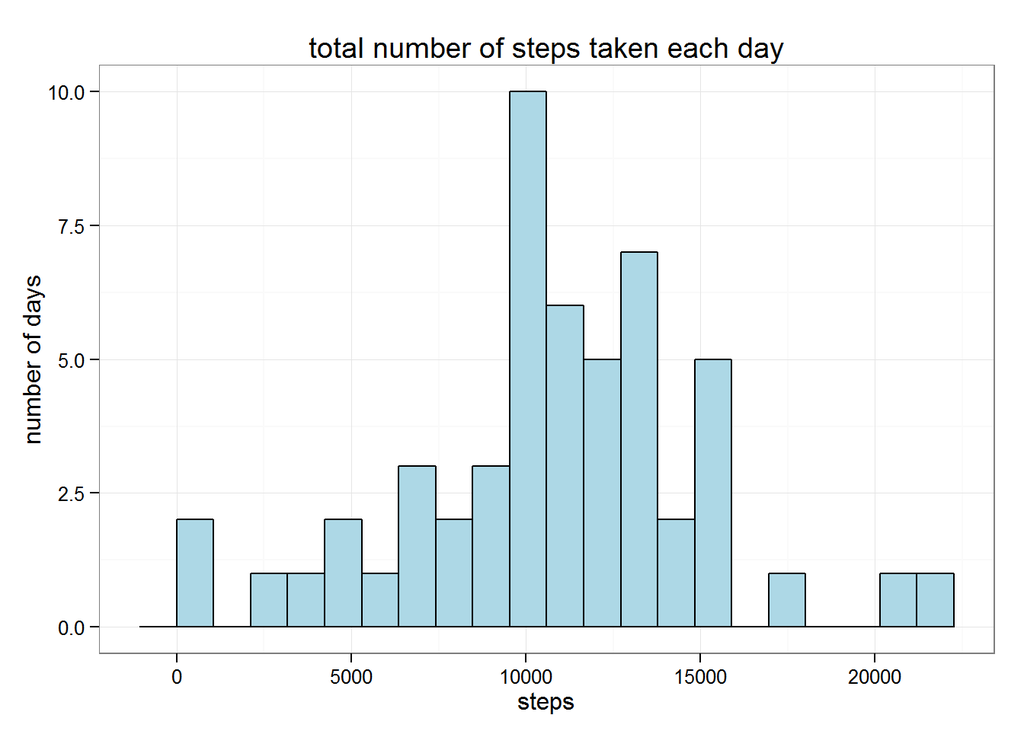

```r
data_sum <- aggregate(steps ~ date, data = data, FUN = sum)
colnames(data_sum)<- c("date", "steps")

g1 <- ggplot(data = data_sum, aes(x = steps))
g1 <- g1 + geom_histogram(aes(y = ..count..),
                          binwidth = max(data_sum$steps) / 20,
                          fill = "lightblue", color = "black")
g1 <- g1 + labs(title = "total number of steps taken each day",
                x = "steps", y = "number of days")
g1 <- g1 + theme_bw() # background black and white
print(g1)
```

# Mean and median number of steps taken each day

The mean of the steps taken each day is given by:

```r
print(mean(data_sum$steps))
```

```
## [1] 10766.19
```

The median of the steps taken each day is given by:

```r
print(median(data_sum$steps))
```

```
## [1] 10765
```

# Time series plot of the average number of steps taken

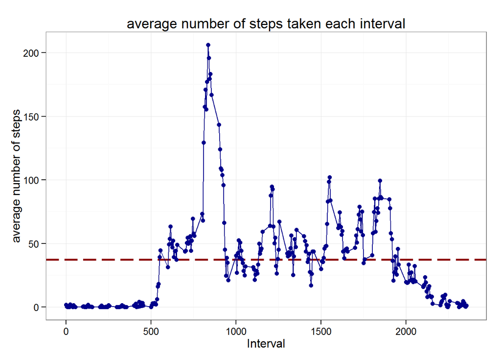

```r
data_interval <- aggregate(steps ~ interval, data = data, FUN = mean)
colnames(data_interval)<- c("interval", "steps")

g2 <- ggplot(data = data_interval, aes(x = interval, y = steps))
g2 <- g2 + geom_hline(yintercept = mean(data_interval$steps), color = "red4", lwd = 1, lty = 5)
g2 <- g2 + geom_line(color = "darkblue")
g2 <- g2 + geom_point(color = "darkblue")
g2 <- g2 + labs(x = "Interval", y = "average number of steps",
                  title = "average number of steps taken each interval")
g2 <- g2 + theme_bw()
print(g2)
```

# The 5-minute interval that, on average, contains the maximum number of steps

```r
interval_max <- subset(data_interval, steps == max(steps))
print(interval_max$interval)
```

```
## [1] 835
```

# Code to describe and show a strategy for imputing missing data

In the rawdata the number of missing steps is given by:

```r
print(nrow(data_raw) - nrow(data))
```

```
## [1] 2304
```

Our imputing strategy is replace NA values for the steps by the mean of that 5-minute interval

```r
data_impute <- data_raw
for (i in 1:nrow(data_impute)) {
    if (is.na(data_impute$steps[i])) {
        data_impute$steps[i] <- data_interval[which(data_interval$interval == data_impute$interval[i]), ]$steps
    }
}
```